# Homework 2: Problems 1–3

Kenneth Luna

In Problems 1–3, we analyze the Russell 2000 Stock Index, adjusted daily closing price, recorded from 10 September 1987 to 11 February 2015.

```r
data <- read.csv("http://ptrckprry.com/course/forecasting/data/russell.csv")
russell <- data$russell
date <- as.Date(data$date)
time <- 1:length(russell)
```

We will work with the mean-adjusted series:

```r
today <- russell - mean(russell)
```

# Problem 1

## Part A

Here is a plot of Today’s Russell versus time, as well as Yesterday’s Russell versus time:

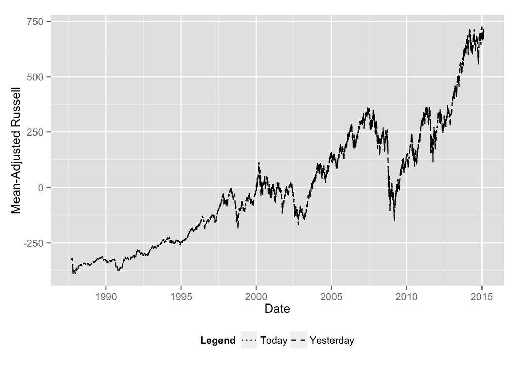

```r
yesterday <- c(NA, today[-length(today)])

library("ggplot2")

ggplot() +
  geom_line(aes(date, today, linetype = "dotted")) +
  geom_line(aes(date, yesterday, linetype = "dashed")) +
  scale_linetype_manual(name = "Legend", values=c("dotted", "dashed"), labels = c("Today", "Yesterday")) + theme(legend.position = "bottom") + ylab("Mean-Adjusted Russell") + xlab("Date")
```

Next, here is a plot of Today’s Russell versus time, as well as 0.5 (Yesterday’s Russell):

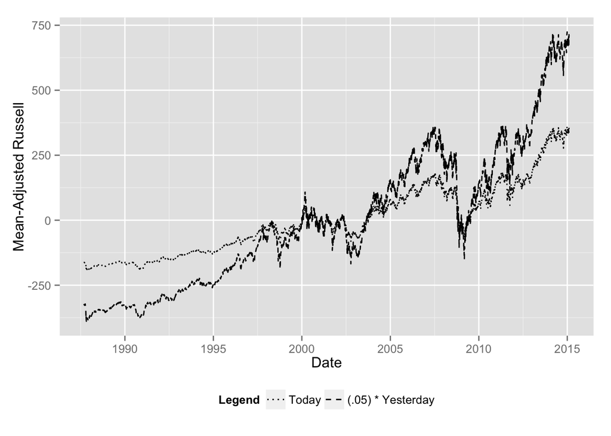

```r
ggplot() +
  geom_line(aes(date, today, linetype = "dotted")) +
  geom_line(aes(date, 0.5 *yesterday, linetype = "dashed"))  +
  scale_linetype_manual(name = "Legend", values=c("dotted", "dashed"), labels = c("Today", "(.05) * Yesterday")) + theme(legend.position = "bottom") +
  ylab("Mean-Adjusted Russell") + xlab("Date")
```

## Part B

**Based on these two plots, which seems to be a better forecast of Today’s Russell: Yesterday’s Russell, or 0.5 (Yesterday’s Russell)?**

Yesterday’s Russell is a better forecast of Today’s Russell. Where the Russell Index was yesterday is a strong indicator of where it will likely be today due to a high degree of autocorrelation. 0.5 (Yesterday’s Russell) under-estimates both the decreases and increases in Today’s Russell.

## Part C

Here are the average squared forecast errors for the two forecasts:

```r
Error1 <- mean((yesterday-today) ^ 2, na.rm = TRUE)
Error2 <- mean(((0.5 * yesterday) - today) ^ 2, na.rm = TRUE)

Error1
```

```
## [1] 57.37113
```

```r
Error2
```

```
## [1] 18409.84
```

**Based on this, which one was better?**

Yesterday’s Russell is better at forecasting Today’s Russell. The average squared error is significantly lower versus that of (0.5 * Yesterday’s Russell).

# Problem 2

## Part A

Here is a plot of Today’s Russell versus Yesterday’s Russell:

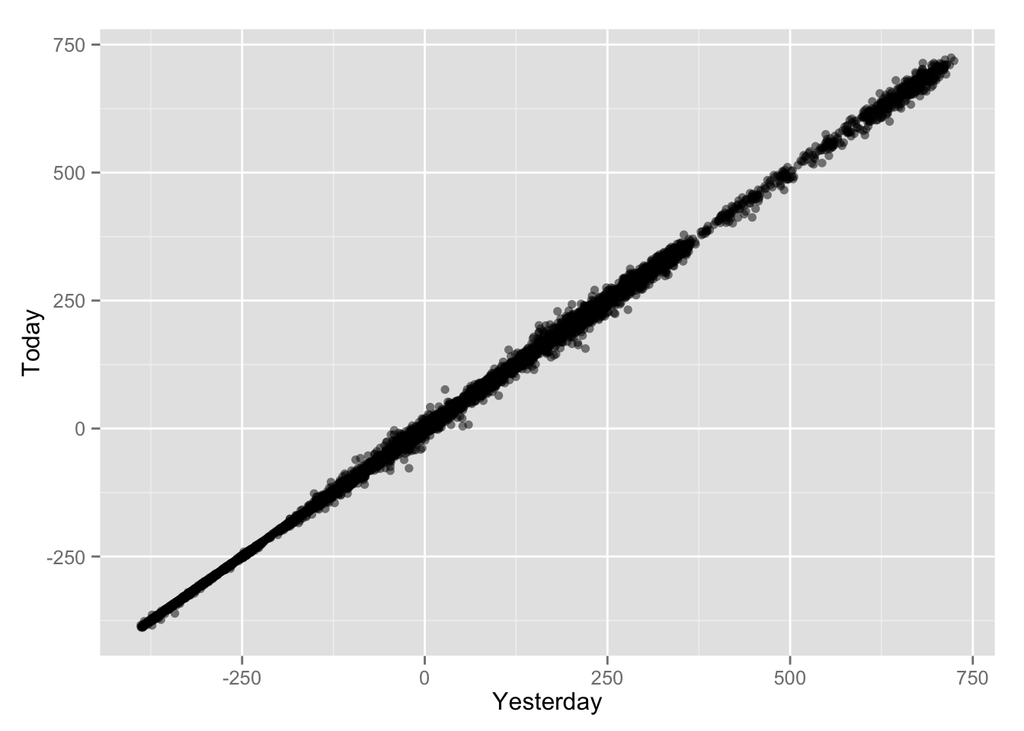

```r
ggplot() + geom_point(aes(yesterday, today), alpha = .5) + ylab("Today") + xlab("Yesterday")
```

**Describe any patterns you see.**

There appears to be a very strong positively linear relationship. If we were to draw a straight line to explain the relationship, we would realize some noise (variance between expected Y versus actual Y). The variance is limited in size. Thus I will conclude that Yesterday’s Russell Index is a very good indicator of Today’s Russell Index.

## Part B

Here is a linear regression fit of Today’s Russell on Yesterday’s Russell:

```r
model <- lm(today ~ yesterday)
summary(model)
```

```
##
## Call:
## lm(formula = today ~ yesterday)
##
## Residuals:
##     Min      1Q  Median      3Q     Max
## -63.819  -2.259   0.130   2.533  48.261
##
## Coefficients:
##              Estimate Std. Error t value Pr(>|t|)
## (Intercept) 0.1493892  0.0911010    1.64    0.101
## yesterday   0.9999972  0.0003362 2974.10   <2e-16 ***
## ---
## Signif. codes:  0 '***' 0.001 '**' 0.01 '*' 0.05 '.' 0.1 ' ' 1
##
## Residual standard error: 7.574 on 6910 degrees of freedom
##   (1 observation deleted due to missingness)
## Multiple R-squared:  0.9992, Adjusted R-squared:  0.9992
## F-statistic: 8.845e+06 on 1 and 6910 DF,  p-value: < 2.2e-16
```

**What is the prediction of Today’s Russell implied by the regression coefficients?**

The prediction based on the regression coefficients is the following:

$today = .9999972 * yesterday + .1493892$

**Is this consistent with your answers to Problem 1, parts B and C?**

Yes this results holds consistent with my findings in Problem 1. Yesterday’s Russell Index is highly correlated with Today’s Russell Index as the coefficient value has an absolute value of 1. I do think there is an issue with this model because the p-value is essentially 0. This might question the validity of this model.

## Part C

The 95% confidence interval for the slope is

```r
confint(model, "yesterday", level = .95)
```

```
##               2.5 %   97.5 %
## yesterday 0.9993381 1.000656
```

**Is the slope in your fitted regression significantly different from 1?**

No, the slope in my fitted regression is not significantly different from 1. It is very close to 1. Again, this is due to the fact that yesterday’s Russell Index is a strong indicator of Today’s Russell Index.

The 95% confidence interval for the intercept is

```r
confint(model, "(Intercept)")
```

```
##                   2.5 %    97.5 %
## (Intercept) -0.02919681 0.3279752
```

**Briefly comment on the intercept as well.**

This intercept value has limited reliability based on its high p-value.

## Part D

**Based on everything you have done so far, do you see any strong evidence that the Russell is *not* a random walk**?

## Part E

Here is the correlation coefficient between Today’s Russell and Yesterday’s Russell:

```r
cor(today, yesterday, use = "complete.obs")
```

```
## [1] 0.9996096
```

**Based on this, how strong is the linear association between Today’s Russell and Yesterday’s Russell?**

The linear relationship is very strong as the absolute value of the correlation coefficient is close to 1.

# Problem 3

## Part A

We define the Russell returns as

```r
ret.today <- diff(russell) / russell[2:length(russell)]
ret.yesterday <- c(NA, ret.today[-length(ret.today)])
```

Here is a plot of Today’s return versus time:

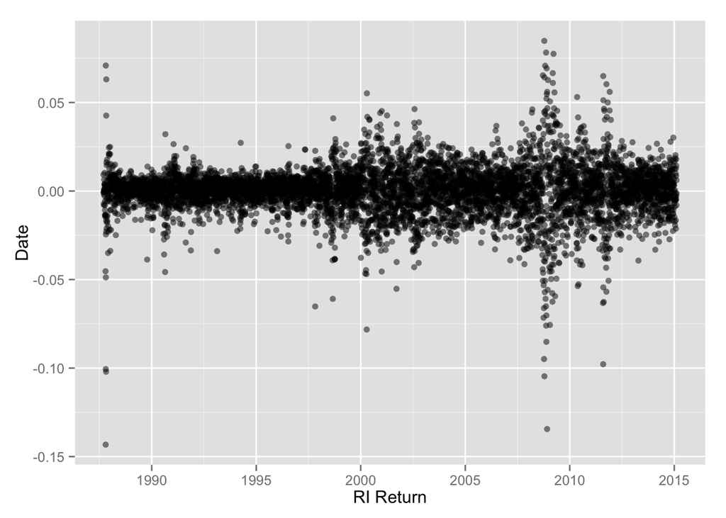

```r
newdate <- date[2:length(date)]
ggplot() + geom_point(aes(newdate, ret.today), alpha = .5) + xlab("RI Return") + ylab("Date")
```

Here are the sample average and standard deviation of the returns:

```r
mean(ret.today)
```

```
## [1] 0.0001958765
```

```r
sd(ret.today)
```

```
## [1] 0.01329809
```

Here is an ordinary t-test of whether the mean returns are zero:

```r
t.test(ret.today)
```

```
##
##  One Sample t-test
##
## data:  ret.today
## t = 1.2246, df = 6911, p-value = 0.2208
## alternative hypothesis: true mean is not equal to 0
## 95 percent confidence interval:
##  -0.0001176770  0.0005094299
## sample estimates:
##    mean of x
## 0.0001958765
```

**Are the mean returns significantly different from zero? Interpret your findings.**

## Part B

Here is a histogram of the Russell returns:

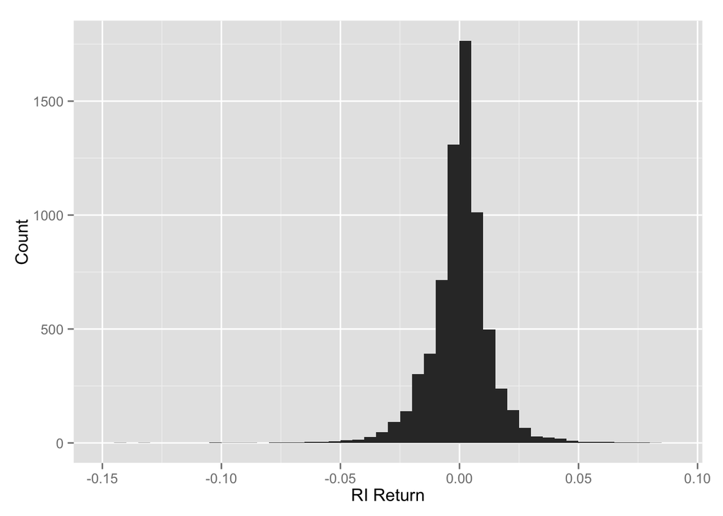

```r
ggplot() + geom_histogram(aes(ret.today), stat = "bin", binwidth = .005) +
  ylab("Count") + xlab("RI Return")
```

Here is a boxplot:

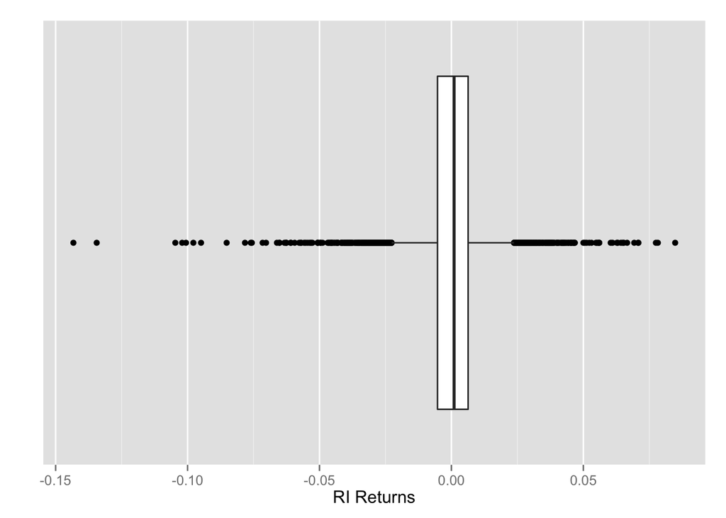

```r
ggplot() + geom_boxplot(aes(x = factor(0), y = ret.today)) + coord_flip() + xlab("") + scale_x_discrete(breaks = NULL) + ylab("RI Returns")
```

Finally, here is a normal quantile-quantile plot:

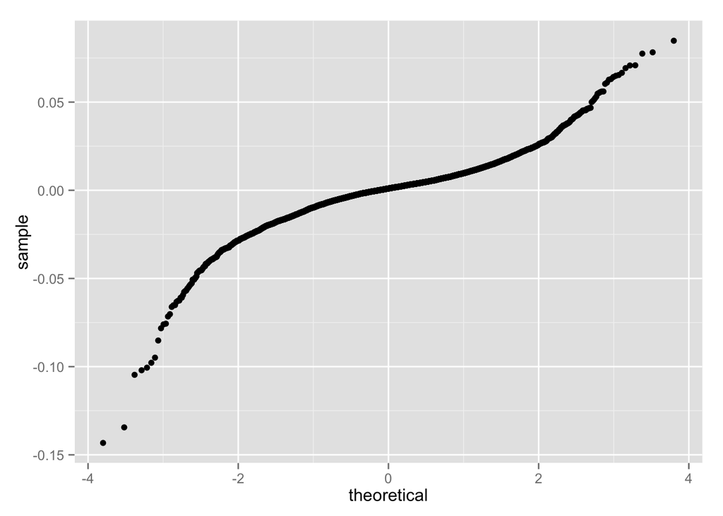

```r
qplot(sample = ret.today, stat="qq")
```

**Do you think that the Russell returns are normally distributed? Explain.**

## Part C

Here is a plot of today’s return versus yesterday’s return

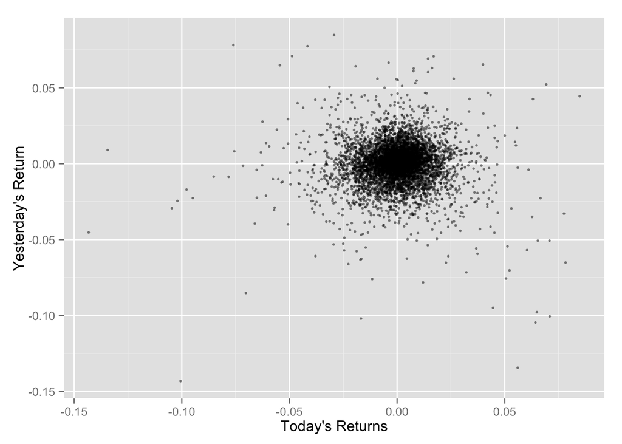

```r
ggplot() + geom_point(aes(ret.today, ret.yesterday), alpha = .5, size = 1) + ylab("Yesterday's Return") + xlab("Today's Returns")
```

Here is a zoomed in plot:

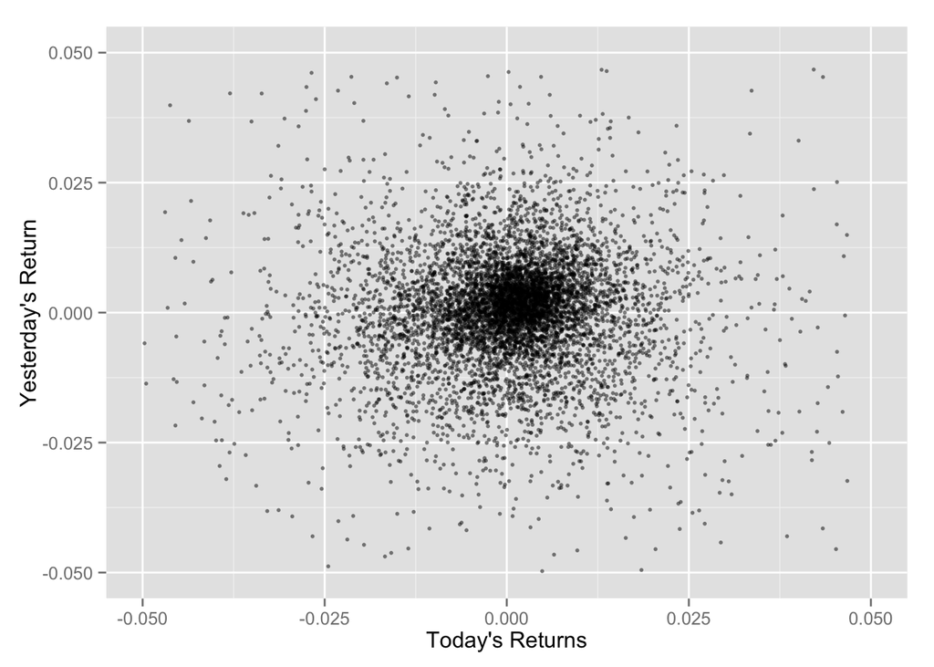

```r
ggplot() + geom_point(aes(ret.today, ret.yesterday), alpha = .5, size = 1) + ylab("Yesterday's Return") + xlab("Today's Returns") +
  xlim(-.05,.05) + ylim(-.05,.05)
```

**Does this plot appear very different from the one in Problem 2(A)? Which seems to be easier to predict: Today’s Russell, or Today’s return?**

## Part D

Here is a linear regression of today’s returns on yesterday’s returns:

```r
model <- lm(ret.today ~ ret.yesterday)
summary(model)
```

```
##
## Call:
## lm(formula = ret.today ~ ret.yesterday)
##
## Residuals:
##       Min        1Q    Median        3Q       Max
## -0.143362 -0.005461  0.000808  0.006133  0.084510
##
## Coefficients:
##                Estimate Std. Error t value Pr(>|t|)
## (Intercept)   0.0001942  0.0001600   1.214    0.225
## ret.yesterday 0.0021011  0.0120303   0.175    0.861
##
## Residual standard error: 0.0133 on 6909 degrees of freedom
##   (1 observation deleted due to missingness)
## Multiple R-squared:  4.415e-06,  Adjusted R-squared:  -0.0001403
## F-statistic: 0.0305 on 1 and 6909 DF,  p-value: 0.8614
```

**What is the prediction of today’s return implied by the regression coefficients?**

The prediction of today’s return implied by the regression coefficients is the following:

$ret.today = ret.yesterday * 0.0021011 + .0001942$

**Are the coefficients statistically significantly different from zero?**

The coefficients are not statistically significantly different from zero because the p-values are greater than the .05 threshold.